# PS8

Jamie Duncan

20/11/2020

#### Section 1

##### Question 1

Read the data into an data frame named electric.

```r
electric <- read_csv("electric-company.csv")
```

##### What sort of variable has R assumed grade is? How will it be treated in a linear model if we use it as an independent variable? Under what circumstances would that be reasonable or unreasonable? Make a new variable from grade that is a factor.

```r
class(electric$grade)
```

```
## [1] "numeric"
```

```r
electric$grade.fac <- as.factor(electric$grade)
```

read_csv has assumed that “grade” is a “numeric variable”

##### How will a linear model treat this new variable? Hint: You may find that summary illuminates the new data set.

```r
summary(electric$grade.fac)
```

```
##  1  2  3  4
## 42 68 40 42
```

Summary displays grade.fac as categories with distinct distributions.

##### Finally, overwrite the existing treatment variable so that it is numerical: 1 when the class is treated and 0

when not.

```r
electric <- electric %>% #replace old df with new df
  mutate(treatment = if_else(treatment == "T", 1, 0)) #overwrite treatment: if the variable equals "T" put a 1, otherwise put a zero
```

Done.

##### Question 2

##### Let’s now consider the effect of treatment. First, fit a linear model that predict post.score with just treatment.

```r
fit.score <- lm(post.score ~ treatment, data = electric)

summary(fit.score)
```

```
##
## Call:
## lm(formula = post.score ~ treatment, data = electric)
##
## Residuals:
##     Min      1Q  Median      3Q     Max
## -55.778  -9.935   4.872  13.397  23.679
##
## Coefficients:
##             Estimate Std. Error t value Pr(>|t|)
## (Intercept)   94.321      1.794   52.58   <2e-16 ***
## treatment      5.657      2.537    2.23   0.0269 *
## ---
## Signif. codes:  0 '***' 0.001 '**' 0.01 '*' 0.05 '.' 0.1 ' ' 1
##
## Residual standard error: 17.58 on 190 degrees of freedom
## Multiple R-squared:  0.0255, Adjusted R-squared:  0.02037
## F-statistic: 4.973 on 1 and 190 DF,  p-value: 0.02692
```

##### Then fit a model uses your factor version of grade as well as treatment.

```r
fit.grade <- lm(post.score ~ treatment + grade.fac, data = electric)
summary(fit.grade)
```

```
##
## Call:
## lm(formula = post.score ~ treatment + grade.fac, data = electric)
##
## Residuals:
##     Min      1Q  Median      3Q     Max
## -33.820  -5.282   1.774   6.547  32.831
##
## Coefficients:
##             Estimate Std. Error t value Pr(>|t|)
## (Intercept)   70.112      1.813  38.682  < 2e-16 ***
## treatment      5.657      1.536   3.684 0.000301 ***
## grade.fac2    24.451      2.088  11.709  < 2e-16 ***
## grade.fac3    33.402      2.351  14.209  < 2e-16 ***
## grade.fac4    39.271      2.322  16.914  < 2e-16 ***
## ---
## Signif. codes:  0 '***' 0.001 '**' 0.01 '*' 0.05 '.' 0.1 ' ' 1
##
## Residual standard error: 10.64 on 187 degrees of freedom
## Multiple R-squared:  0.6485, Adjusted R-squared:  0.641
## F-statistic: 86.26 on 4 and 187 DF,  p-value: < 2.2e-16
```

##### Summarise both models in terms of how much of the variance in post.score they “explain” and the median size of their errors.

The first model suggests a weak but statistically significant positive relationship between treatment and post.score. The second model is more refined. It indicates that not only is treatment significantly positively related to post.score but that post.score is also strongly positively related to a student’s grade-level at a higher magnitude than treatment.

##### Now, consider each model’s treatment coefficient. Are the estimates of this coefficient different in the two models? Why do you think that is?

The coefficient figures are the same however the p-value indicates a stronger correlation in the second. This could be because the factor variable of grade level helps to explain away some of the variations in the treatment effect. I note that the median residual is much lower in the second model.

##### Question 3

##### Now make another model that uses the factor version of grade and pre.score (the reading score before the year begins) to predict post.score. Is this model better? If so, in what ways?

```r
fit.score <- lm(post.score ~ pre.score + grade.fac, data = electric)

summary(fit.score)
```

```
##
## Call:
## lm(formula = post.score ~ pre.score + grade.fac, data = electric)
##
## Residuals:
##     Min      1Q  Median      3Q     Max
## -23.171  -2.949  -0.063   2.709  31.941
##
## Coefficients:
##              Estimate Std. Error t value Pr(>|t|)
## (Intercept)  60.13815    1.46887  40.942  < 2e-16 ***
## pre.score     0.82192    0.05701  14.418  < 2e-16 ***
## grade.fac2  -22.99587    3.61164  -6.367 1.45e-09 ***
## grade.fac3  -31.59005    4.80894  -6.569 4.88e-10 ***
## grade.fac4  -34.85958    5.40126  -6.454 9.11e-10 ***
## ---
## Signif. codes:  0 '***' 0.001 '**' 0.01 '*' 0.05 '.' 0.1 ' ' 1
##
## Residual standard error: 7.583 on 187 degrees of freedom
## Multiple R-squared:  0.8215, Adjusted R-squared:  0.8177
## F-statistic: 215.1 on 4 and 187 DF,  p-value: < 2.2e-16
```

```r
fit.score$coefficients
```

```
## (Intercept)   pre.score  grade.fac2  grade.fac3  grade.fac4
##  60.1381471   0.8219166 -22.9958729 -31.5900509 -34.8595756
```

The models are measuring different things so it’s hard to say that one is better than another in general. However, the differences are interesting. We can see that in the first, there is a strong positive relationship between grade level and post-score. In the second we see that trend inverted. My hypothesis is that by incorporating the pre.score, one can observe that there are diminishing returns year over year as grade increases get lower and lower. Moreover, the t-value for the pre.score variable and $R^2$ is higher for the second model indicating improved certainty. We can say that pre-score is a more reliable indicator of post-score than is treatment. That said, treatment still has a significant effect on post.score outcomes.

##### Question 4

Now let’s consider the effect of treatment within each grade. We can use the lm function’s subset argument to fit the model on just a subset of all the rows in the data set. For example, we can fit a model of the relationship of post.score to treatment and pre.score just in grade 2 like this: mod <- lm(post.score ~ treatment + pre.score, data = electric, subset = grade == 2)

Fit a linear model predicting post.score using treatment and pre.score for each grade. You need to follow the following procedures: 1. Define a function named fit_reg that returns the coefficient on treatment. The function should have two arguments: the entire data (data_all) and the grade (grade_subset).  
2. Use a for loop and call the fit_reg() function for each grade (1 to 4). Store what the fit_reg() function returns in a variable.  
3. Print out the coefficient on treatment using the print() function.  
4. Briefly comment on the result. There are now four treatment effects. How do they differ as grade increases?

```r
data_all <- electric # two arguments
grade_subset <- unique(electric$grade.fac)

fit_reg <- function(df, param){ #Define a function named fit_reg that returns the coefficient on treatment. The function should have two arguments: the entire data (data_all) and the grade (grade_subset).
  mod <- lm(post.score ~ treatment + pre.score, data = df, subset = grade == param)
  modb <- mod$coefficients
}
#Use a for loop and call the fit_reg() function for each grade (1 to 4). Store what the fit_reg() function returns in a variable.
for (i in grade_subset){
  model <- fit_reg(data_all, i)
  print(model)
}
```

```
## (Intercept)   treatment   pre.score
##  -11.022851    8.786518    5.108442
## (Intercept)   treatment   pre.score
##  37.4287665   4.2657655   0.7889114
## (Intercept)   treatment   pre.score
##  40.5842440   1.9097259   0.6846634
## (Intercept)   treatment   pre.score
##  41.9947259   1.7014364   0.6558295
```

This model confirms my above suspicion regarding the diminishing returns of educational programming.

##### Question 5

##### Now let’s try to learn about separate grade effects in a single model. One way to do this is to interact

treatment with grade. Here’s a general modeling principle:

##### If you think the effect of variable A varies according to the values of variable B, then you should think of adding an interaction between A and B in your model Reminder: In the lm formula interface this amounts to adding an `A:B` term. For example, if A and B interact to predict Y then the formula would be `Y ~ A + B + A:B` which would fit the model $Yi = \beta_0 + \beta_AA_i + \beta_BB_i + \beta_{AB} (A_i × B_i) + \epsilon_i$ an alternative syntax to fit this model is `A*B`. So to fit the model above using this notation the formula is `Y ~ A * B`

##### Since we always want to have A and B if we have an A:B term, the * notation makes sure we don’t forget any of them. But they are equivalent.

##### Fit a model of all the grades that includes pre.score, treatment, grade (factor version), the factor version of grade interacted with treatment, and the factor version of grade interacted with pre.score (this is called a fully interacted model). How would you construct grade-specific treatment effects from these coefficients? Show an example for grade 2.

```r
fit.inter <- lm(post.score ~ grade.fac * treatment * pre.score, data = electric)

summary(fit.inter)
```

```
##
## Call:
## lm(formula = post.score ~ grade.fac * treatment * pre.score,
##     data = electric)
##
## Residuals:
##      Min       1Q   Median       3Q      Max
## -19.6759  -2.5237   0.2688   2.0055  14.7022
##
## Coefficients:
##                                Estimate Std. Error t value Pr(>|t|)
## (Intercept)                    -15.9258     9.1061  -1.749 0.082051 .
## grade.fac2                      53.4955    10.3727   5.157 6.69e-07 ***
## grade.fac3                      57.9700    15.2267   3.807 0.000194 ***
## grade.fac4                      53.7660    15.3583   3.501 0.000588 ***
## treatment                       16.5255    11.4536   1.443 0.150847
## pre.score                        5.4223     0.5779   9.382  < 2e-16 ***
## grade.fac2:treatment           -12.6399    14.1454  -0.894 0.372772
## grade.fac3:treatment           -17.2482    19.9287  -0.865 0.387945
## grade.fac4:treatment             0.8467    26.7959   0.032 0.974828
## grade.fac2:pre.score            -4.6353     0.5821  -7.964 1.99e-13 ***
## grade.fac3:pre.score            -4.7528     0.5917  -8.033 1.32e-13 ***
## grade.fac4:pre.score            -4.7266     0.5899  -8.013 1.49e-13 ***
## treatment:pre.score             -0.4964     0.7269  -0.683 0.495542
## grade.fac2:treatment:pre.score   0.5016     0.7353   0.682 0.496054
## grade.fac3:treatment:pre.score   0.5242     0.7468   0.702 0.483629
## grade.fac4:treatment:pre.score   0.3493     0.7615   0.459 0.647065
## ---
## Signif. codes:  0 '***' 0.001 '**' 0.01 '*' 0.05 '.' 0.1 ' ' 1
##
## Residual standard error: 5.395 on 176 degrees of freedom
## Multiple R-squared:  0.915,  Adjusted R-squared:  0.9077
## F-statistic: 126.2 on 15 and 176 DF,  p-value: < 2.2e-16
```

```r
fit.inter
```

```
##
## Call:
## lm(formula = post.score ~ grade.fac * treatment * pre.score,
##     data = electric)
##
## Coefficients:
##                    (Intercept)                      grade.fac2
##                       -15.9258                         53.4955
##                     grade.fac3                      grade.fac4
##                        57.9700                         53.7660
##                      treatment                       pre.score
##                        16.5255                          5.4223
##           grade.fac2:treatment            grade.fac3:treatment
##                       -12.6399                        -17.2482
##           grade.fac4:treatment            grade.fac2:pre.score
##                         0.8467                         -4.6353
##           grade.fac3:pre.score            grade.fac4:pre.score
##                        -4.7528                         -4.7266
##            treatment:pre.score  grade.fac2:treatment:pre.score
##                        -0.4964                          0.5016
## grade.fac3:treatment:pre.score  grade.fac4:treatment:pre.score
##                         0.5242                          0.3493
```

##### Question 6

##### Use a bar plot to visualize the grade-specific treatment effects that you calculated in the previous question. Briefly interpret the result. Hint: You can make a bar plot using a barplot() function (textbook p.81)

```r
list.mod <- vector("list", )


for (i in grade_subset){
  list.mod[[i]] <- fit_reg(data_all, i)
  results <- list.mod
}
results
```

```
## $`1`
## (Intercept)   treatment   pre.score
##  -11.022851    8.786518    5.108442
##
## $`2`
## (Intercept)   treatment   pre.score
##  37.4287665   4.2657655   0.7889114
##
## $`3`
## (Intercept)   treatment   pre.score
##  40.5842440   1.9097259   0.6846634
##
## $`4`
## (Intercept)   treatment   pre.score
##  41.9947259   1.7014364   0.6558295
```

```r
results1 <- results[[1]] #extracting the numbers from the output
results2 <- results[[2]]
results3 <- results[[3]]
results4 <- results[[4]]

results1 <- tidy(results1)#cleaning and converting the output into a data frame.
results2 <- tidy(results2)
results3 <- tidy(results3)
results4 <- tidy(results4)

combined <- rbind(results1, results2, results3, results4) #combining into one data frame
combined <- combined %>% # subsetting to pull just the treatment effects
  filter(names == "treatment")
```

```r
combined[1:4,1] <- paste(c(1:4)) #renaming the rows by grade
```

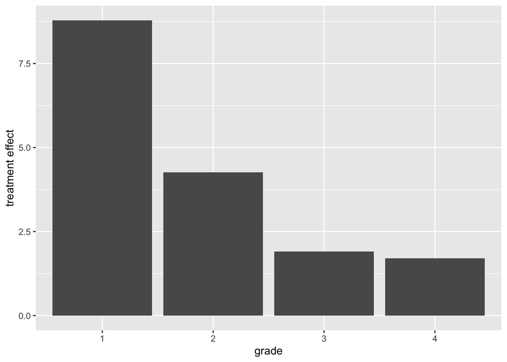

```r
ggplot(combined, aes(x = names, y = x))+ #plotting the treatment effects by grade.
  geom_bar(stat = "identity")+
  xlab("grade")+
  ylab("treatment effect")
```

Phew. Looking forward to figuring out how to do this more e3fficiently but here it is. The average treatment effect declines as grade increases.

#### Section 2

```r
imm <- read_csv("immig.csv")
library(rstatix)
library(ggcorrplot)
```

##### Question 1

##### Start by examining the distribution of immigration attitudes (as factor variables). What is the proportion of people who are willing to increase the quota for high-skilled foreign professionals (h1bvis.supp) or support immigration from India (indimm.supp)?

```r
imm$h1bvis.supp <- as.factor(imm$h1bvis.supp)
"h1bvis.supp"
```

```
## [1] "h1bvis.supp"
```

```r
prop.table(summary(imm$h1bvis.supp))
```

```
##           0        0.25         0.5        0.75           1        NA's
## 0.304501324 0.225066196 0.295675199 0.101500441 0.063548102 0.009708738
```

```r
imm$indimm.supp <- as.factor(imm$indimm.supp)
"indimm.supp"
```

```
## [1] "indimm.supp"
```

```r
prop.table(summary(imm$indimm.supp))
```

```
##           0        0.25         0.5        0.75           1        NA's
## 0.285083848 0.179170344 0.394527802 0.098852604 0.032656664 0.009708738
```

As I interpret the 5 point scale, 6% of respondents were “very supportive” of H-1B visas and a further 10% were “supportive”. Concurrently, 3% of respondents were strongly supportive of Indian immigration and 10% were supportive of it.

##### Now compare the distribution of two distinct measures of cultural threat: explicit stereotyping about Indians (expl.prejud) and implicit bias against Indian Americans (impl.prejud). In particular, create a scatterplot, add a linear regression line to it, and calculate the correlation coefficient. Based on these results, what can you say about their relationship?

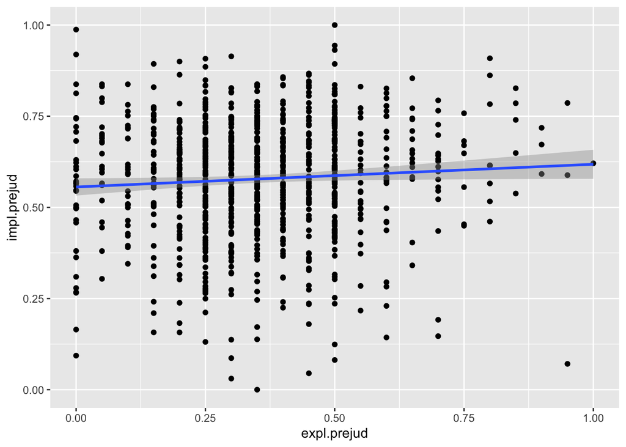

```r
ggplot(imm, aes(x = expl.prejud, y = impl.prejud))+
  geom_point()+
  geom_smooth(method = lm, formula = y ~ x)
```

```r
fit.prejud <- lm(impl.prejud ~ expl.prejud, data = imm)
summary(fit.prejud)
```

```
##
## Call:
## lm(formula = impl.prejud ~ expl.prejud, data = imm)
##
## Residuals:
##      Min       1Q   Median       3Q      Max
## -0.57767 -0.09568  0.01443  0.11346  0.43164
##
## Coefficients:
##             Estimate Std. Error t value Pr(>|t|)
## (Intercept)  0.55588    0.01203  46.219   <2e-16 ***
## expl.prejud  0.06227    0.03029   2.056   0.0401 *
## ---
## Signif. codes:  0 '***' 0.001 '**' 0.01 '*' 0.05 '.' 0.1 ' ' 1
##
## Residual standard error: 0.1613 on 893 degrees of freedom
##   (238 observations deleted due to missingness)
## Multiple R-squared:  0.004712,   Adjusted R-squared:  0.003597
## F-statistic: 4.227 on 1 and 893 DF,  p-value: 0.04007
```

```r
cor.test(imm$impl.prejud, imm$expl.prejud)
```

```
##
##  Pearson's product-moment correlation
##
## data:  imm$impl.prejud and imm$expl.prejud
## t = 2.0561, df = 893, p-value = 0.04007
## alternative hypothesis: true correlation is not equal to 0
## 95 percent confidence interval:
##  0.003124615 0.133570560
## sample estimates:
##        cor
## 0.06864096
```

There is a weak positive relationship between explicit and implicit prejudice that is significant to 0.05.

##### Question 2

##### Compute the correlations between all four policy attitude and cultural threat measures. Do you agree that cultural threat is an important predictor of immigration attitudes as claimed in the literature?

```r
imm$h1bvis.supp <- as.numeric(imm$h1bvis.supp) #converting to numbers
imm$indimm.supp <- as.numeric(imm$indimm.supp)
imm$expl.prejud <- as.numeric(imm$expl.prejud)
imm$impl.prejud <- as.numeric(imm$impl.prejud)

cordata <- imm %>%
  select(h1bvis.supp, indimm.supp, expl.prejud, impl.prejud) %>% #selecting relevant variables
  cor_mat() %>% #running a correlation matrix
  print()
```

```
## # A tibble: 4 x 5
##   rowname     h1bvis.supp indimm.supp expl.prejud impl.prejud
## * <chr>             <dbl>       <dbl>       <dbl>       <dbl>
## 1 h1bvis.supp        1           0.62      -0.16       -0.12
## 2 indimm.supp        0.62        1         -0.32       -0.15
## 3 expl.prejud       -0.16       -0.32       1           0.069
## 4 impl.prejud       -0.12       -0.15       0.069       1
```

I don’t have all the information to agree or disagree with a broad generalization like cultural threat theory. The correlation matrix does support the common sense conclusion that people who display implicit and explicit bias against ethnic Indians are less likely to support immigration and (to a slightly lesser extent) H-1B visas.

##### If the labor market hypothesis is correct, opposition to H-1B visas should also be more pronounced among those who are economically threatened by this policy such as individuals in the high-technology sector. At the same time, tech workers should not be more or less opposed to general Indian immigration because of any economic considerations. First, regress H-1B and Indian immigration attitudes on the indicator variable for tech workers (tech.whitcol). Do the results support the hypothesis? Is the relationship different from the one involving cultural threat and, if so, how?

```r
tech.fit <- lm(tech.whitcol ~ h1bvis.supp + indimm.supp, data = imm)
summary(tech.fit)
```

```
##
## Call:
## lm(formula = tech.whitcol ~ h1bvis.supp + indimm.supp, data = imm)
##
## Residuals:
##      Min       1Q   Median       3Q      Max
## -0.08596 -0.05862 -0.05211 -0.04528  0.97523
##
## Coefficients:
##              Estimate Std. Error t value Pr(>|t|)
## (Intercept)  0.063066   0.016883   3.735 0.000197 ***
## h1bvis.supp -0.011282   0.007100  -1.589 0.112339
## indimm.supp  0.006835   0.007736   0.884 0.377150
## ---
## Signif. codes:  0 '***' 0.001 '**' 0.01 '*' 0.05 '.' 0.1 ' ' 1
##
## Residual standard error: 0.2232 on 1119 degrees of freedom
##   (11 observations deleted due to missingness)
## Multiple R-squared:  0.002268,   Adjusted R-squared:  0.000485
## F-statistic: 1.272 on 2 and 1119 DF,  p-value: 0.2807
```

Tech workers appear to be more opposed to H-1B visas than to Indian immigration in general. Neither estimate is statistically significant.

##### Question 3

When examining hypotheses, it is always important to have an appropriate comparison group. One may argue that comparing tech workers to everybody else as we did in Question 2 may be problematic due to a variety of confounding variables (such as skill level and employment status). First, create a single factor variable group which takes a value of tech if someone is employed in tech, whitecollar if someone is employed in other “white-collar” jobs (such as law or finance), other if someone is employed in any other sector, and unemployed if someone is unemployed. Then, compare the support for H-1B across these conditions by using the linear regression. Interpret the results: is this comparison more or less supportive of the labor market hypothesis than the one in Question 2?

```r
imm.wc <- imm
imm.wc$whitecollar[imm.wc$employed == 1] <- "other"
imm.wc$whitecollar[imm.wc$employed == 0] <- "unemployed"
imm.wc$whitecollar[imm.wc$tech.whitcol == 1] <- "tech"
imm.wc$whitecollar[imm.wc$nontech.whitcol == 1] <- "whitecollar"
```

```r
h1bfit <- lm(h1bvis.supp ~ factor(whitecollar), data = imm.wc)
summary(h1bfit)
```

```
##
## Call:
## lm(formula = h1bvis.supp ~ factor(whitecollar), data = imm.wc)
##
## Residuals:
##     Min      1Q  Median      3Q     Max
## -1.5690 -1.3843 -0.3843  0.6157  2.8136
##
## Coefficients:
##                                Estimate Std. Error t value Pr(>|t|)
## (Intercept)                     2.38429    0.05537  43.063   <2e-16 ***
## factor(whitecollar)tech        -0.19785    0.16595  -1.192    0.233
## factor(whitecollar)unemployed   0.01084    0.07596   0.143    0.887
## factor(whitecollar)whitecollar  0.18468    0.16721   1.104    0.270
## ---
## Signif. codes:  0 '***' 0.001 '**' 0.01 '*' 0.05 '.' 0.1 ' ' 1
##
## Residual standard error: 1.202 on 1118 degrees of freedom
##   (11 observations deleted due to missingness)
## Multiple R-squared:  0.002675,   Adjusted R-squared:  -1.234e-06
## F-statistic: 0.9995 on 3 and 1118 DF,  p-value: 0.3923
```

None of these estimates is considered statistically significant, although the trend of tech workers specifically having less support for H-1B visas continues and is slightly intensified in this model.

##### Now, one may also argue that those who work in the tech sector are disproportionately young and male which may confound our results. To account for this possibility, fit another linear regression but also include age and female as pre-treatment covariates (in addition to group). Does it change the results and, if so, how?

```r
h1bfit2 <- lm(h1bvis.supp ~ factor(whitecollar) + age + female, data = imm.wc)
summary(h1bfit2)
```

```
##
## Call:
## lm(formula = h1bvis.supp ~ factor(whitecollar) + age + female,
##     data = imm.wc)
##
## Residuals:
##     Min      1Q  Median      3Q     Max
## -1.9044 -1.1764 -0.1607  0.7401  3.1433
##
## Coefficients:
##                                 Estimate Std. Error t value Pr(>|t|)
## (Intercept)                     3.037413   0.136928  22.183  < 2e-16 ***
## factor(whitecollar)tech        -0.303913   0.165983  -1.831   0.0674 .
## factor(whitecollar)unemployed   0.055454   0.075804   0.732   0.4646
## factor(whitecollar)whitecollar  0.221165   0.165285   1.338   0.1811
## age                            -0.009919   0.002414  -4.109 4.26e-05 ***
## female                         -0.301458   0.075155  -4.011 6.45e-05 ***
## ---
## Signif. codes:  0 '***' 0.001 '**' 0.01 '*' 0.05 '.' 0.1 ' ' 1
##
## Residual standard error: 1.187 on 1116 degrees of freedom
##   (11 observations deleted due to missingness)
## Multiple R-squared:  0.02889,    Adjusted R-squared:  0.02454
## F-statistic: 6.641 on 5 and 1116 DF,  p-value: 4.189e-06
```

In this model we have some significant p-values. Tech workers hold disproportionately negative views of H-1B visas measured as significant to 0.1. Age is negatively correlated with significance of 0.05. There is a significant negative relationship between gender (female) and support for the H-1B visas measured at 0.001.

##### Finally, fit a linear regression model with all threat indicators (group, expl.prejud, impl.prejud) and calculate its R2. How much of the variation is explained? Based on the model fit, what can you conclude about the role of threat factors?

```r
threat.fit <-  lm(h1bvis.supp ~ factor(group) + expl.prejud + impl.prejud, data = imm.wc)
summary(threat.fit)
```

```
##
## Call:
## lm(formula = h1bvis.supp ~ factor(group) + expl.prejud + impl.prejud,
##     data = imm.wc)
##
## Residuals:
##     Min      1Q  Median      3Q     Max
## -1.9845 -1.0959 -0.1572  0.7048  3.0410
##
## Coefficients:
##                Estimate Std. Error t value Pr(>|t|)
## (Intercept)      3.0096     0.2316  12.997  < 2e-16 ***
## factor(group)1   0.4108     0.2476   1.659  0.09749 .
## factor(group)2   0.1887     0.1827   1.033  0.30181
## factor(group)3   0.1640     0.1815   0.904  0.36645
## expl.prejud     -1.0107     0.2222  -4.548 6.16e-06 ***
## impl.prejud     -0.7668     0.2454  -3.124  0.00184 **
## ---
## Signif. codes:  0 '***' 0.001 '**' 0.01 '*' 0.05 '.' 0.1 ' ' 1
##
## Residual standard error: 1.18 on 889 degrees of freedom
##   (238 observations deleted due to missingness)
## Multiple R-squared:  0.03834,    Adjusted R-squared:  0.03293
## F-statistic: 7.088 on 5 and 889 DF,  p-value: 1.641e-06
```

```r
summary(threat.fit)$r.squared
```

```
## [1] 0.03833731
```

Much more variation is explained by implicit and explicit prejudice. Explicit prejudice is significantly negatively correlated with support for H-1B at 0.001. Implicit prejudice is significantly negatively associated with support for H-1B at 0.01. this model explains xenophobia more effectively than the labour market indicators. In fact, group 1 (which captures all whitecollar workers) has a weakly significant (at 0.1) positive relationship with support for H-1B.

##### Question 4

##### Besides economic and cultural threat, many scholars also argue that gender is an important predictor of immigration attitudes. While there is some evidence that women are slightly less opposed to immigration than men, it may also be true that gender conditions the very effect of other factors such as cultural threat. To see if it is indeed the case, fit a linear regression of H-1B support on the interaction between gender and implicit prejudice.

```r
gender.fit <- lm(h1bvis.supp ~ female * impl.prejud, data = imm.wc)
summary(gender.fit)
```

```
##
## Call:
## lm(formula = h1bvis.supp ~ female * impl.prejud, data = imm.wc)
##
## Residuals:
##     Min      1Q  Median      3Q     Max
## -2.3297 -1.2154 -0.2121  0.7380  2.8846
##
## Coefficients:
##                    Estimate Std. Error t value Pr(>|t|)
## (Intercept)          3.3961     0.2190  15.504  < 2e-16 ***
## female              -0.8577     0.2798  -3.066  0.00223 **
## impl.prejud         -1.4769     0.3725  -3.965 7.86e-05 ***
## female:impl.prejud   1.0233     0.4715   2.170  0.03024 *
## ---
## Signif. codes:  0 '***' 0.001 '**' 0.01 '*' 0.05 '.' 0.1 ' ' 1
##
## Residual standard error: 1.182 on 1005 degrees of freedom
##   (124 observations deleted due to missingness)
## Multiple R-squared:  0.03086,    Adjusted R-squared:  0.02797
## F-statistic: 10.67 on 3 and 1005 DF,  p-value: 6.615e-07
```

##### Then, create a plot with the predicted level of H-1B support (y-axis) across the range of implicit bias (x-axis) by gender. Considering the results, would you agree that gender alters the relationship between cultural threat and immigration attitudes?

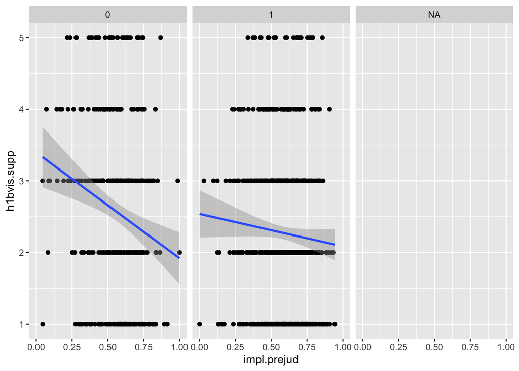

```r
ggplot(imm.wc, aes(x = impl.prejud, y = h1bvis.supp))+
  geom_point()+
  geom_smooth(method = lm, formula = y ~ x)+
  facet_wrap(~ female)
```

This plot demonstrates that women are less influenced by implicit bias in their positions on H-1B.

##### Age is another important covariate. Fit two regression models in which H-1B support is either a linear or quadratic function of age. Compare the results by plotting the predicted levels of support (y-axis) across the whole age range (x-axis). Would you say that people become more opposed to immigration with age?

```r
lfit.age <- lm(h1bvis.supp ~ age, data = imm.wc)
qfit.age <- lm(h1bvis.supp ~ age + I(age^2), data = imm.wc)

summary(lfit.age)
```

```
##
## Call:
## lm(formula = h1bvis.supp ~ age, data = imm.wc)
##
## Residuals:
##     Min      1Q  Median      3Q     Max
## -1.6505 -1.2775 -0.2428  0.7030  2.8960
##
## Coefficients:
##              Estimate Std. Error t value Pr(>|t|)
## (Intercept)  2.806709   0.120740  23.246  < 2e-16 ***
## age         -0.008676   0.002393  -3.625 0.000302 ***
## ---
## Signif. codes:  0 '***' 0.001 '**' 0.01 '*' 0.05 '.' 0.1 ' ' 1
##
## Residual standard error: 1.195 on 1120 degrees of freedom
##   (11 observations deleted due to missingness)
## Multiple R-squared:  0.0116, Adjusted R-squared:  0.01071
## F-statistic: 13.14 on 1 and 1120 DF,  p-value: 0.0003021
```

```r
summary(qfit.age)
```

```
##
## Call:
## lm(formula = h1bvis.supp ~ age + I(age^2), data = imm.wc)
##
## Residuals:
##     Min      1Q  Median      3Q     Max
## -2.2406 -1.2130 -0.2167  0.7687  2.7944
##
## Coefficients:
##               Estimate Std. Error t value Pr(>|t|)
## (Intercept)  4.3013508  0.3059592  14.059  < 2e-16 ***
## age         -0.0793017  0.0135214  -5.865 5.91e-09 ***
## I(age^2)     0.0007502  0.0001414   5.305 1.36e-07 ***
## ---
## Signif. codes:  0 '***' 0.001 '**' 0.01 '*' 0.05 '.' 0.1 ' ' 1
##
## Residual standard error: 1.181 on 1119 degrees of freedom
##   (11 observations deleted due to missingness)
## Multiple R-squared:  0.03584,    Adjusted R-squared:  0.03412
## F-statistic:  20.8 on 2 and 1119 DF,  p-value: 1.35e-09
```

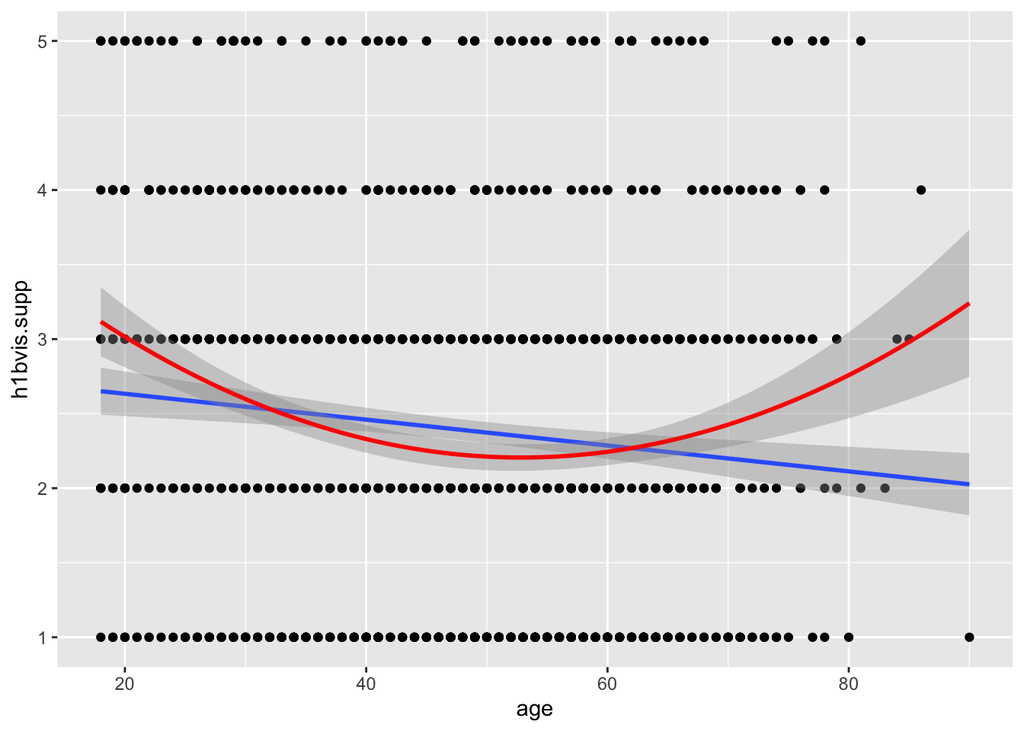

```r
ggplot(imm.wc, aes(x = age, y = h1bvis.supp))+
  geom_point()+
  geom_smooth(method = lm, formula = y ~ x)+
  geom_smooth(method = lm, formula = y ~ x + I(x^2), color = "red")
```